# 06_20_update

Molly Jenkins

June 20, 2017

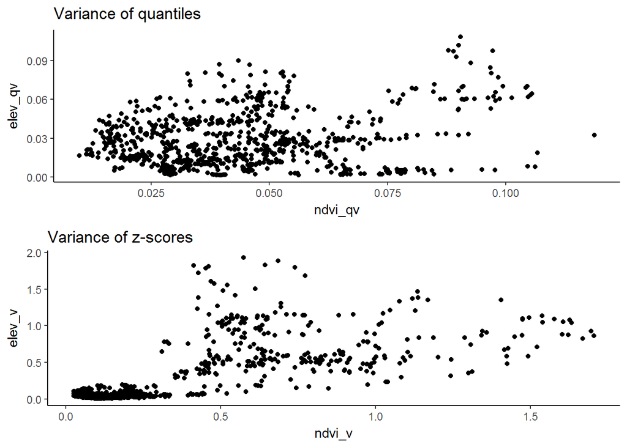

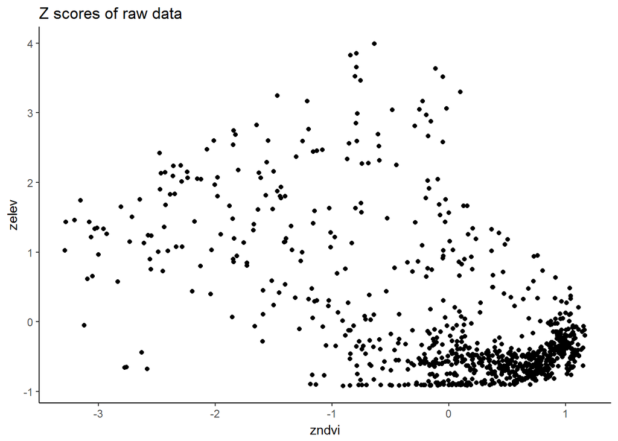

Looking at the values for the different coefficients versus the variance in the environmental variables

We expected high heterogeneity/high variance/high convex polygon volume to correspond to lower occupancy averages, characterized by high inflexion point values (inflexion point i occurs further along x axis) and lower asymptote values (asymptote A plateaus out at a lower y value due to the occupancy average being pulled down by a higher occurence of transients).

We expected low heterogeneity/low variance/low convex polygon volume to correspond to higher occupancy averages, characterized by low inflexion point values (inflexion point i occurs early along x axis) and higher asymptote values (asymptote A plataeus out closer to maximum occupancy).

This would look like: points with high variance (high variance in elev/NDVI, high polygon volume would have high i values (low occ values) AND points with low variance and volume would have low i values (high occupancy). This would be a positive linear relationship.

The inverse being true for A values: high variance and volume would correspond to low A values (low occupancy) and low variance and volume would correspond to high A values. This would be a negative linear relationship.

Instead, I got the following:

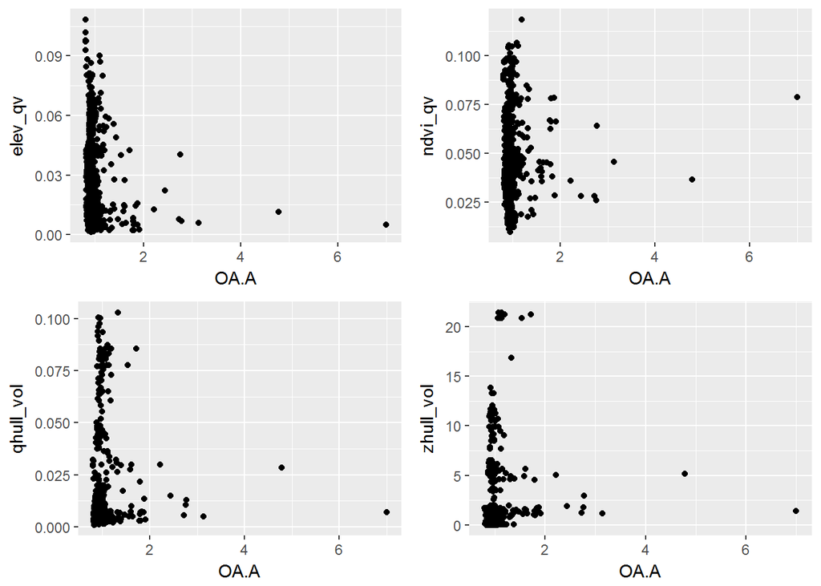

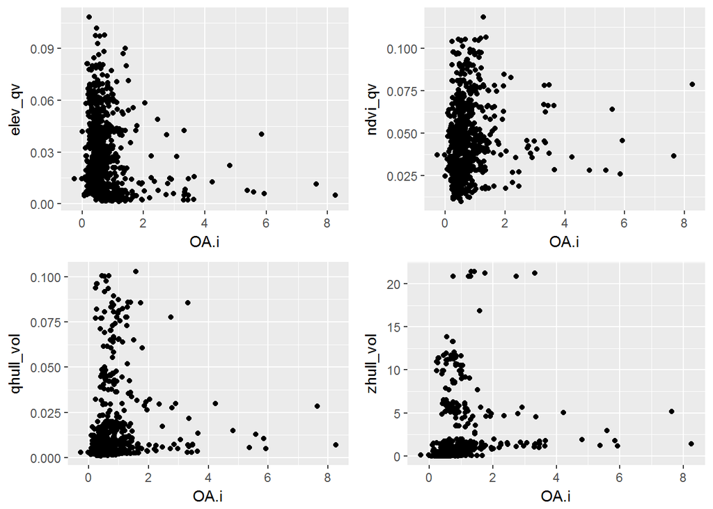

Additionally, when I look at the maxiumum values for my A and i points, I get the following:

```r
max(env_coefs$OA.A, na.rm = T) #7
```

```
## [1] 7.002112
```

```r
max(env_coefs$OA.i, na.rm = T) #8
```

```
## [1] 8.25874
```

^ the coefficients are calculated using a trycatch system in “alt_occ_scale.R” lines 167-329, including all files necessary to extract coefs.